# Title: Predictors of land-surface temperature and air pollution across Canadian cities are largely scale and city dependent

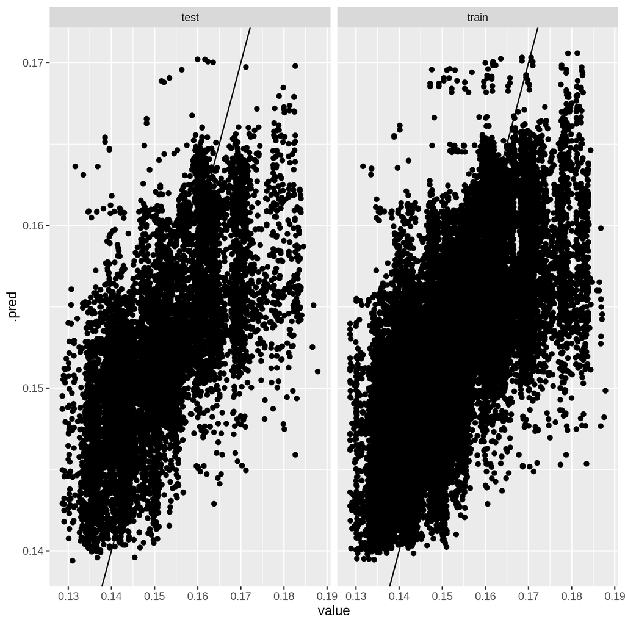

**Figure A3.4j. Model performance plot for ozone model at the neighbourhood scale.**

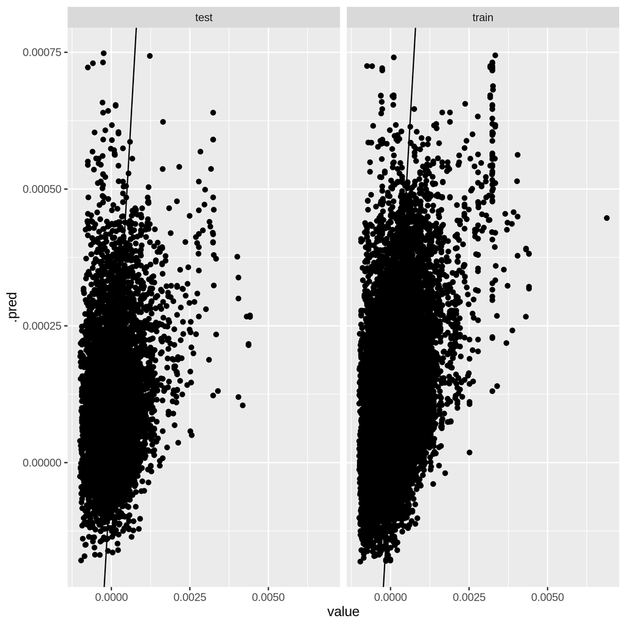

**Figure A3.4k. Model performance plot for sulfur dioxide model at the neighbourhood scale.**

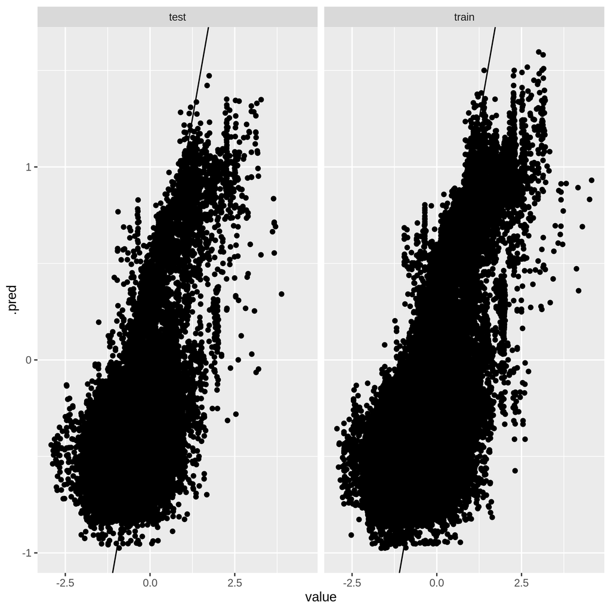

**Figure A3.4l. Model performance plot for UV aerosols model at the neighbourhood scale.**

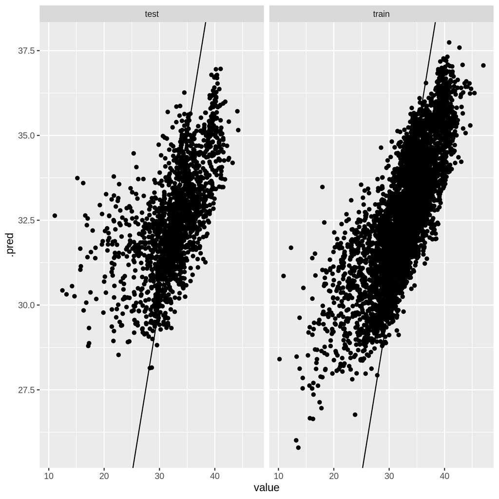

**Figure A3.4m. Model performance plot for temperature model at the street scale.**

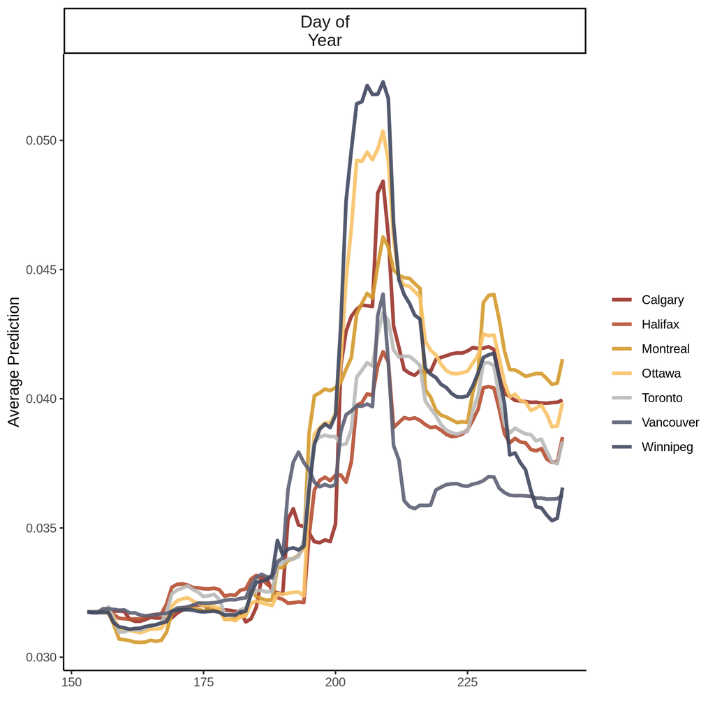

**Figure A3.5a. Accumulated local effects (ALE) plot for carbon monoxide model at the city scale.**

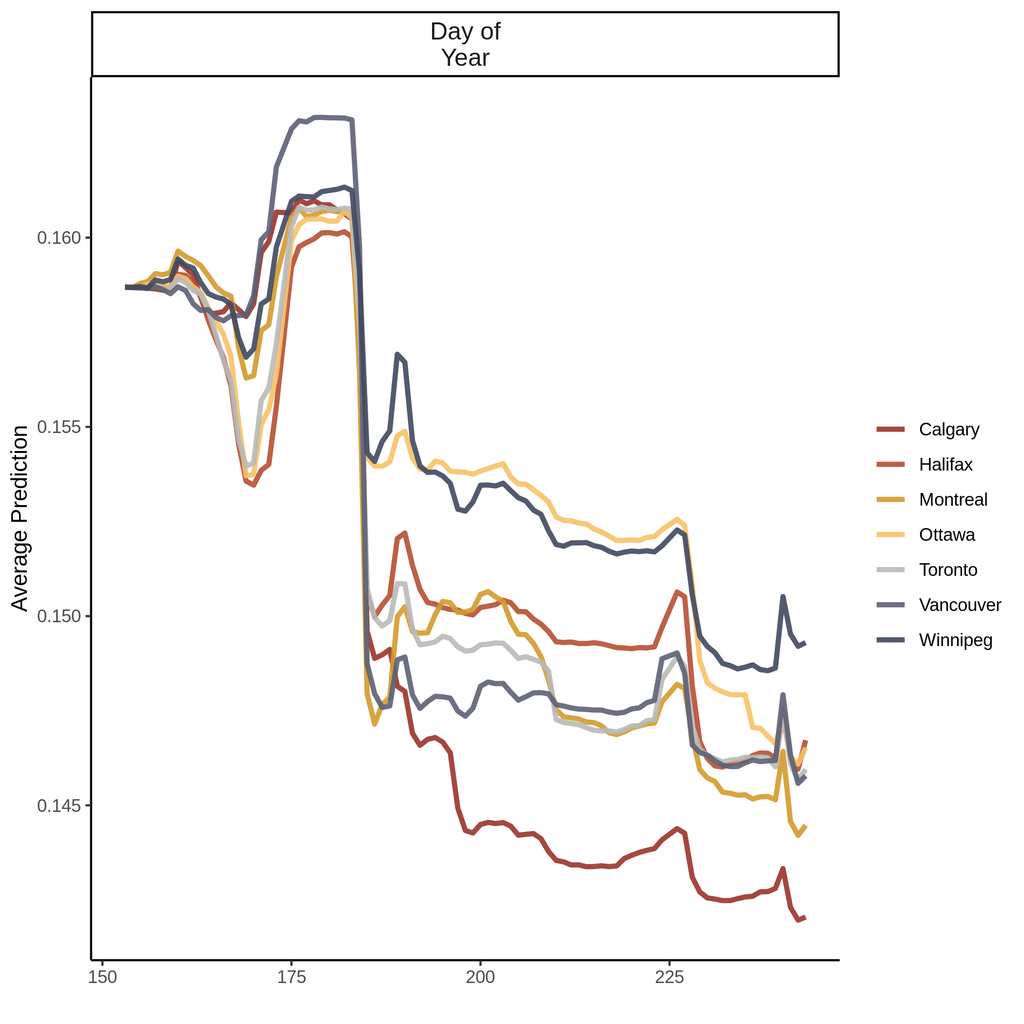

**Figure A3.5b. Accumulated local effects (ALE) plot for ozone model at the city scale.**

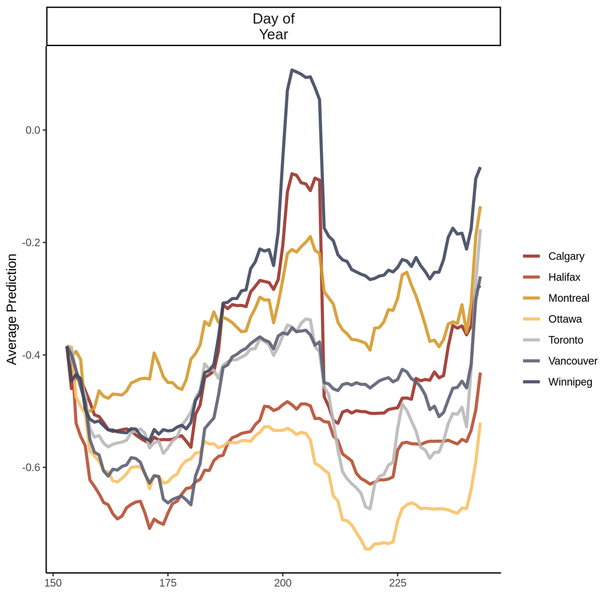

**Figure A3.5c. Accumulated local effects (ALE) plot for UV aerosols model at the city scale.**

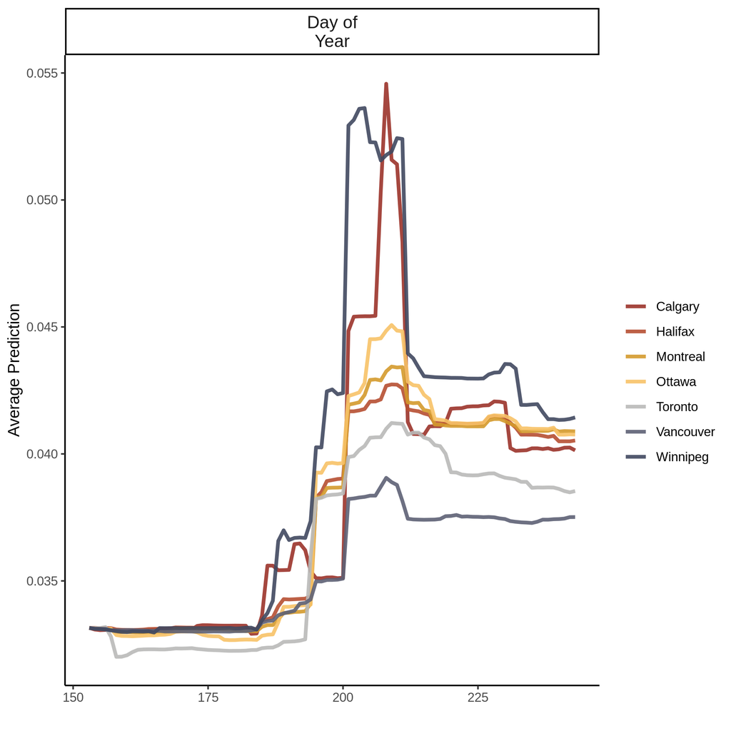

**Figure A3.5d. Accumulated local effects (ALE) plot for carbon monoxide model at the neighbourhood scale.**

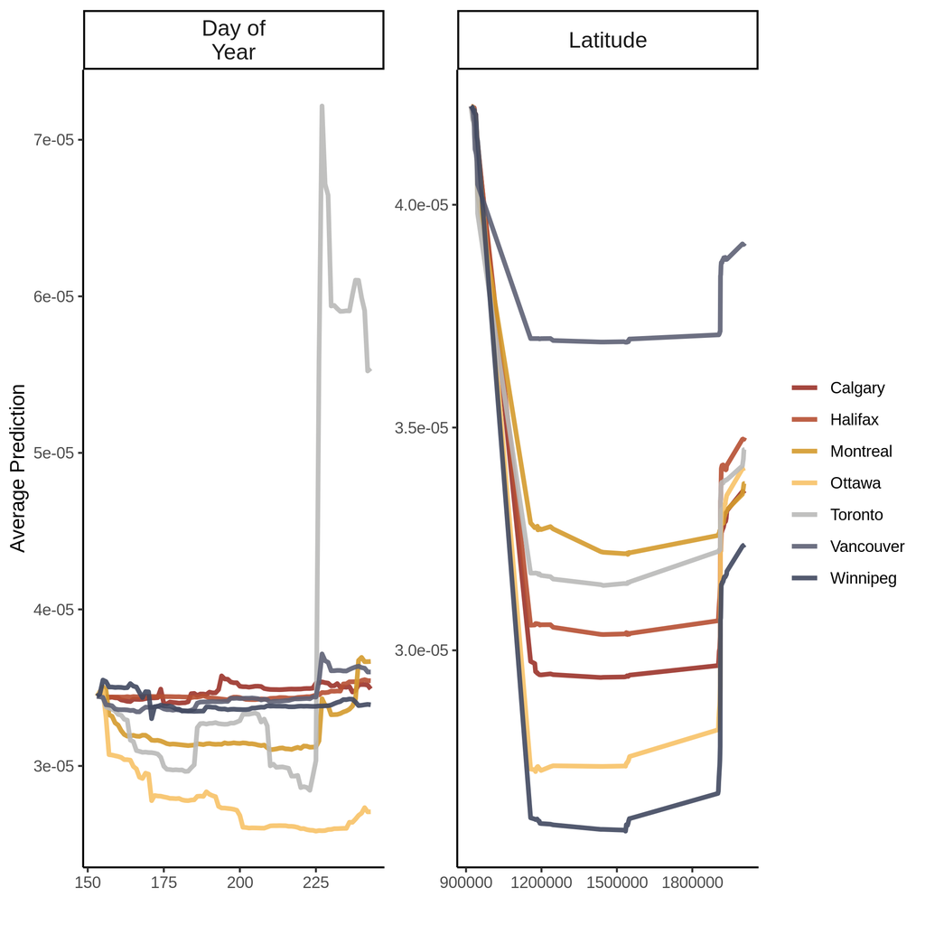

**Figure A3.5e. Accumulated local effects (ALE) plot for nitrogen dioxide model at the neighbourhood scale.**

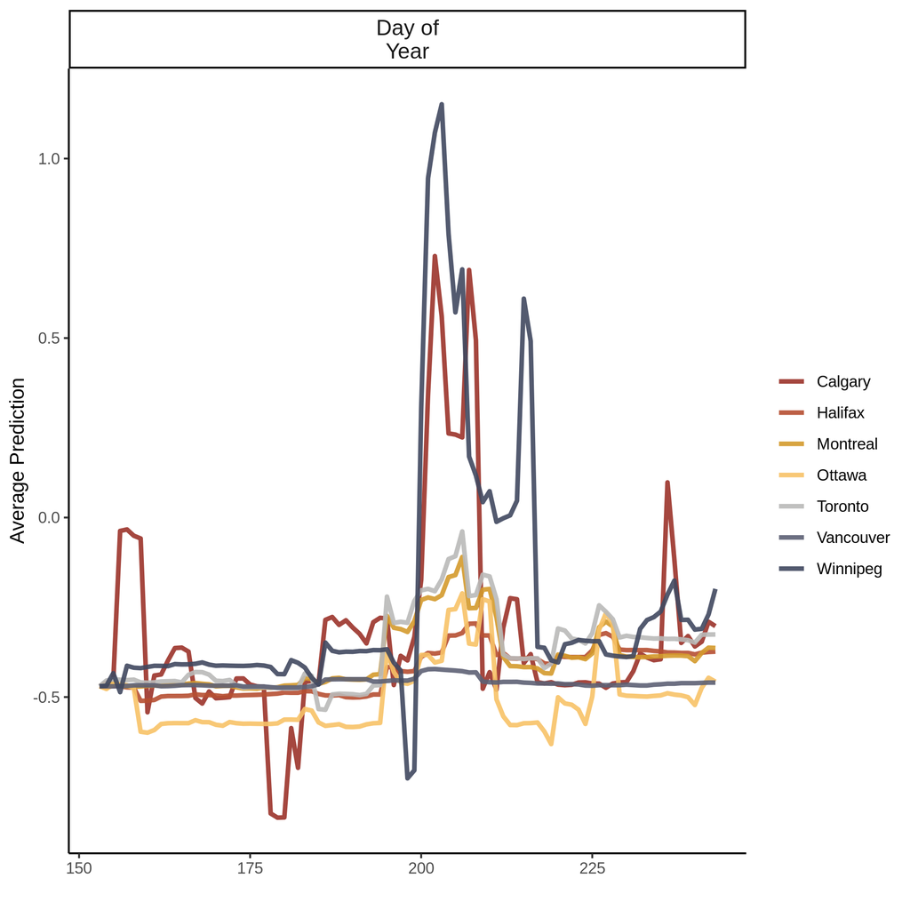

**Figure A3.5f. Accumulated local effects (ALE) for UV aerosols model at the neighbourhood scale.**

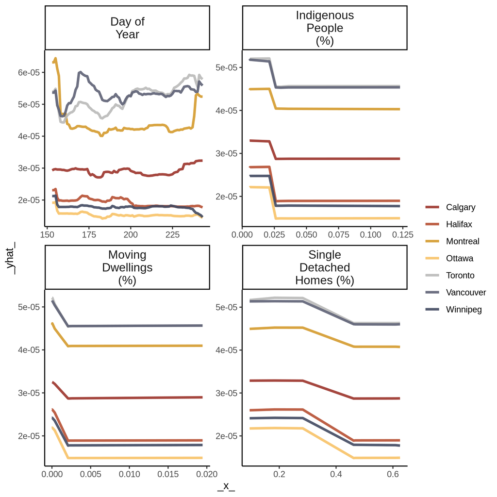

**Figure A3.6a. Partial dependency plot for nitrogen dioxide model at the city scale.**

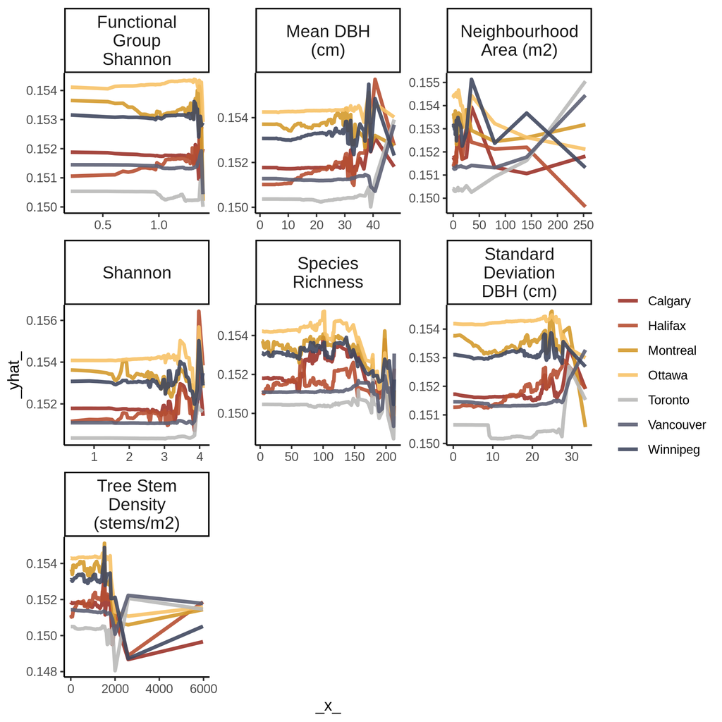

**Figure A3.6b. Partial dependency plot for ozone model at the neighbourhood scale.**